# Wordle Data Analysis Final

Brenda Luis

2025-11-13

# Introduction

Wordle is a popular online word puzzle where players guess a five letter word within six attempts. Each guess provides feedback: letters in the correct position are highlighted in green, letters in the word but in the wrong position appear yellow, and letters not in the word are gray. Beyond being an engaging game, Wordle presents a rich dataset for analysis. Words have unique characteristics, such as vowel-consonant balance, repeated letters, rare letters, Scrabble scores, and frequency of usage.

This analysis explores these patterns across 1600+ Wordle words to uncover trends in word selection, letter placement, and other structural features. By examining the relationships between word properties, frequency, and temporal trends, this project aims to provide insights into the hidden patterns that shape the daily puzzle.

[figure not shown]

# Questions to answer

- Which letters appear more frequently in Wordle solutions?
- Which letters appear more frequently in Wordle solutions by position?
- Which letter pairs (bigrams) appear most often in Wordle solutions?
- How does the bigram frequency change depending on where they appear in the word?
- Do repeated letter Wordle answers follow seasonal or monthly patterns across different years?
- Is there a relationship between a word’s frequency in English and its Scrabble point value?

# Required Packages

- **ggplot2**: visualizing letter frequencies, birgrams, and distributions
- **dplyr**: filtering, summarizing, and transforming the data
- **tidyr**: reshaping data (pivoting)
- **kableExtra**: table formatting
- **gridExtra**: arrange plots together neatly
- **calendR**: to create monthly Wordle heatmap

# Dataset Information

## Description

The dataset contains official Wordle answers from 2021 to 2025, scraped from:

https://wordfinder.yourdictionary.com/wordle/answers/

Each row represents one day’s solution.

## Format

wordle_data is a data frame with 1609 rows and 28 variables:

| **Variable** | **Type** | **Description** |
| --- | --- | --- |
| Date | date | Publication date of the puzzle |
| Wordle.Number | integer | Sequential ID of the puzzle |
| Answer | character | Correct 5-letter Wordle answer |
| Weekday | character | Day of the week |
| Month | character | Month name |
| Day | integer | Day of month |
| Year | integer | Year |
| Has.Repeated.Letters | integer | 1 if the word contains repeated letters |
| All.unique.letters | integer | 1 if all letters in the word are unique |
| Starts.with.vowel | integer | 1 if the word starts with a vowel (A/E/I/O/U) |
| Ends.with.vowel | integer | 1 if the word ends with a vowel (A/E/I/O/U) |
| Num.vowels | integer | Number of vowels in the word |
| Num.consonants | integer | Number of consonants in the word |
| Ends.with.Y | integer | 1 if the word ends with “Y” |
| Has.rare.letter | integer | 1 if the word contains Q, Z, X, or J |
| Contains.common.prefix | integer | 1 if it contains RE, UN, IN, IM, DE, EX, or BE |
| Contains.common.suffix | integer | 1 if it contains ED, ER, LY, ES, ST, NT, TH, CH, SH |
| P1–P5 | character | Letters in each of the 5 positions |
| Word.Frequency | numeric | English frequency score (0–1) |
| Scrabble.score | integer | Scrabble point value of the word |
| Frequency.category | character | Categorized frequency level |
| Top.row.letters | integer | Count of top-row keyboard letters |
| Mid.row.letters | integer | Count of middle-row keyboard letters |
| Bottom.row.letters | integer | Count of bottom-row keyboard letters |

# Data Preparation

| Date | Wordle.Number | Answer | Weekday | Month | Day | Year | Has.repeated.letters | Starts.with.vowel | Ends.with.vowel | Num.vowels | Num.consonants | Has.rare.letter | Contains.common.suffix | All.unique.letters | P1 | P2 | P3 | P4 | P5 | Contains.common.prefix | Word.Frequency | Scrabble.score | Frequency.category | Top.row.letters | Mid.row.letters | Bottom.row.letters | Ends.with.Y |
| --- | --- | --- | --- | --- | --- | --- | --- | --- | --- | --- | --- | --- | --- | --- | --- | --- | --- | --- | --- | --- | --- | --- | --- | --- | --- | --- | --- |
| 2021-08-02 | 44 | DIGIT | Monday | August | 2 | 2021 | 1 | 0 | 0 | 2 | 3 | 0 | 0 | 0 | D | I | G | I | T | 0 | 5.90e-06 | 7 | uncommon | 3 | 2 | 0 | 0 |
| 2022-07-07 | 383 | AGAPE | Thursday | July | 7 | 2022 | 1 | 1 | 1 | 3 | 2 | 0 | 0 | 0 | A | G | A | P | E | 0 | 4.00e-07 | 8 | rare | 2 | 3 | 0 | 0 |
| 2022-07-17 | 393 | WACKY | Sunday | July | 17 | 2022 | 0 | 0 | 0 | 1 | 4 | 0 | 0 | 1 | W | A | C | K | Y | 0 | 2.00e-06 | 17 | uncommon | 2 | 2 | 1 | 1 |
| 2023-05-01 | 681 | RANGE | Monday | May | 1 | 2023 | 0 | 0 | 1 | 2 | 3 | 0 | 0 | 1 | R | A | N | G | E | 0 | 1.32e-04 | 6 | common | 2 | 2 | 1 | 0 |
| 2024-02-06 | 962 | WHICH | Tuesday | February | 6 | 2024 | 1 | 0 | 0 | 1 | 4 | 0 | 1 | 0 | W | H | I | C | H | 0 | 2.00e-03 | 16 | common | 2 | 2 | 1 | 0 |
| 2024-05-05 | 1051 | DECAL | Sunday | May | 5 | 2024 | 0 | 0 | 0 | 2 | 3 | 0 | 0 | 1 | D | E | C | A | L | 1 | 1.00e-06 | 8 | uncommon | 1 | 3 | 1 | 0 |
| 2024-07-11 | 1118 | CAMEO | Thursday | July | 11 | 2024 | 0 | 0 | 1 | 3 | 2 | 0 | 0 | 1 | C | A | M | E | O | 0 | 3.00e-06 | 9 | uncommon | 2 | 1 | 2 | 0 |
| 2024-08-03 | 1141 | SCALE | Saturday | August | 3 | 2024 | 0 | 0 | 1 | 2 | 3 | 0 | 0 | 1 | S | C | A | L | E | 0 | 6.76e-05 | 7 | uncommon | 1 | 3 | 1 | 0 |
| 2024-09-28 | 1197 | BRAIN | Saturday | September | 28 | 2024 | 0 | 0 | 0 | 2 | 3 | 0 | 0 | 1 | B | R | A | I | N | 0 | 8.71e-05 | 7 | uncommon | 2 | 1 | 2 | 0 |
| 2025-07-06 | 1478 | ATRIA | Sunday | July | 6 | 2025 | 1 | 1 | 1 | 3 | 2 | 0 | 0 | 0 | A | T | R | I | A | 0 | 2.00e-07 | 5 | rare | 3 | 2 | 0 | 0 |

# Exploratory Data Analysis

# Which letters appear more frequently in Wordle solutions?

This project begins by looking at how often each letter appears across all Wordle solutions. Even though every answer is a five-letter English word, some letters show up much more often than others. Checking this overall distribution helps us understand the general patterns Wordle follows. Common letters make certain guesses stronger, while rare letters can make a puzzle harder if they appear. The table and bar chart below show how each letter is used in the full list of solutions.

| Letter | Counts | Type |
| --- | --- | --- |
| E | 876 | Vowel |
| A | 706 | Vowel |
| R | 630 | Consonant |
| O | 546 | Vowel |
| T | 539 | Consonant |
| L | 496 | Consonant |
| I | 455 | Vowel |
| S | 437 | Consonant |
| N | 406 | Consonant |
| C | 322 | Consonant |
| U | 308 | Vowel |
| H | 289 | Consonant |
| D | 273 | Consonant |
| Y | 258 | Consonant |
| P | 245 | Consonant |
| G | 217 | Consonant |
| M | 217 | Consonant |
| B | 188 | Consonant |
| F | 160 | Consonant |
| K | 141 | Consonant |
| W | 129 | Consonant |
| V | 106 | Consonant |
| X | 31 | Consonant |
| Z | 29 | Consonant |
| Q | 22 | Consonant |
| J | 19 | Consonant |

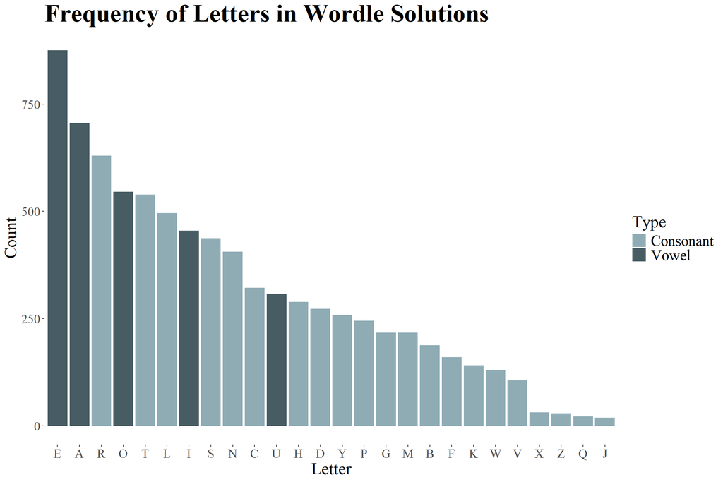

| most_common_letter | frequency |
| --- | --- |
| E | 876 |

| least_common_letter | frequency |
| --- | --- |
| J | 19 |

The results show that E is the most common letter, followed by A, R, O, and T. These letters appear throughout many standard English words, so it makes sense that Wordle uses them often. On the other end, letters like X, Z, Q, and J appear very rarely. Because of this gap between common and uncommon letters, first guesses that include frequent vowels and consonants are usually more effective. This gives us a clearer picture of Wordle’s overall word patterns before we look at *where* the letters appear inside the words.

# Which letters appear more frequently in Wordle solutions by position?

I’ve always wondered whether Wordle’s selection algorithm follows any patterns when choosing daily solutions. Do certain letters tend to appear in specific positions more than others? To investigate, we can look at the frequency of letters by position. English has strong tendencies here, such as common starting letters and typical word endings. Recognizing these positional patterns helps explain why some guesses feel more informative in Wordle. The table below highlights the top letters for each position, followed by a heatmap showing the full distribution.

| Position | Letter | Counts |
| --- | --- | --- |
| P1 | S | 237 |
| P1 | C | 133 |
| P1 | B | 121 |
| P2 | A | 206 |
| P2 | O | 202 |
| P2 | R | 189 |
| P3 | A | 241 |
| P3 | O | 188 |
| P3 | I | 175 |
| P4 | E | 207 |
| P4 | N | 130 |
| P4 | S | 120 |
| P5 | E | 327 |
| P5 | Y | 221 |
| P5 | T | 186 |

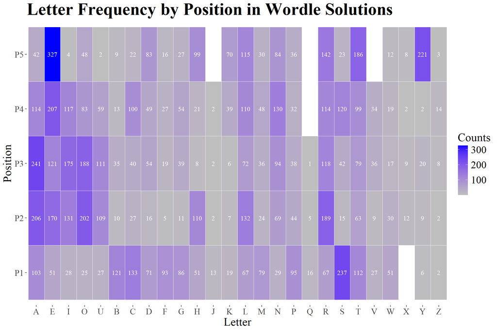

The heatmap reveals several clear patterns. Consonants like S, T, B, and C dominate the first position, which aligns with common English word structures. In the final position, letters such as E, Y, and T appear frequently, whereas letters like J, Q, and V never occur at the end. These patterns illustrate how predictable certain positions can be and why some guesses help narrow down solutions more efficiently. Observing letter behavior by position deepens our understanding of English word structure in the context of Wordle.

## FUN FACT

One observation I’ve made while playing Wordle is that four letter words converted to five letters by adding a plural “S” are quite rare.

Examples of this kind of plural would be:

- CART -> CARTS
- BOOK -> BOOKS
- CARD -> CARDS

This heatmap corroborates my theory: out of 1,600+ Wordle solutions only 23 words end in “S”. In the future, it would be interesting to add a column to my data indicating whether a word is a noun, verb, or plural in Python, which could help further test this theory.

# So *how* is this data useful?

To put this into practice, consider the partial Wordle solution BAKE_.

Possible answers include:

- BAKED
- BAKER
- BAKES

Analyzing the letter frequency for Position 5 can guide our choice.

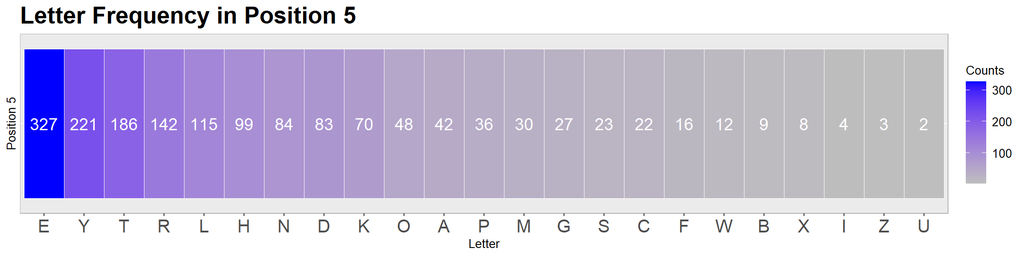

| Position | Letter | Frequency |
| --- | --- | --- |
| P5 | R | 142 |
| P5 | D | 83 |
| P5 | S | 23 |

Based on this data, the most likely answer is BAKER.

# Which letter pairs (bigrams) appear most often in Wordle solutions?

To move beyond single-letter patterns, it’s useful to examine bigrams, or pairs of letters that appear consecutively in a word. English words tend to reuse certain pairs frequently, and Wordle solutions reflect these tendencies. Identifying the most common bigrams helps reveal the structure of Wordle answers and provides insight into why some guesses narrow down the solution more efficiently than others.

| Bigram | Counts |
| --- | --- |
| ER | 134 |
| IN | 94 |
| ST | 91 |
| RA | 80 |
| AR | 79 |
| RO | 78 |
| AL | 75 |
| CH | 75 |
| RE | 75 |
| EA | 73 |

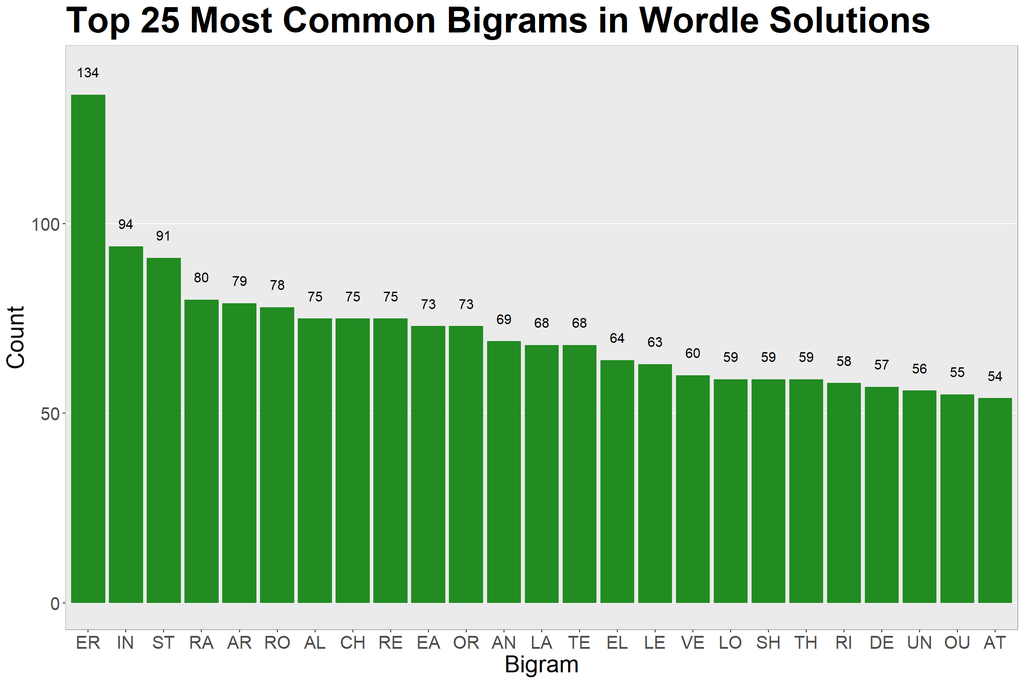

The bar chart shows the twenty-five most common bigrams across all Wordle solutions. Many of these pairs reflect standard English patterns. ER is the most frequent bigram, followed by IN, ST, RA, and AR. These pairs often appear in common word endings or roots. Understanding which bigrams are frequent helps explain why certain guesses are more effective when solving a puzzle.

# How does the bigram frequency change depending on where they appear in the word?

Next, we examine bigrams by their position within the word. Each five letter Wordle solution has four bigram positions:

- B1: letters 1–2 (start of word)
- B2: letters 2–3
- B3: letters 3–4
- B4: letters 4–5 (end of word)

B1 reflects common word beginnings, while B4 reflects typical endings. English has strong positional patterns, and analyzing each position reveals how Wordle solutions follow these structures.

| Position | Bigram | Counts |
| --- | --- | --- |
| B1 | ST | 52 |
| B1 | SH | 34 |
| B1 | SP | 33 |
| B2 | RO | 51 |
| B2 | RA | 49 |
| B2 | RI | 43 |
| B3 | AR | 38 |
| B3 | IN | 37 |
| B3 | AS | 31 |
| B3 | EA | 31 |
| B4 | ER | 95 |
| B4 | CH | 39 |
| B4 | SE | 38 |

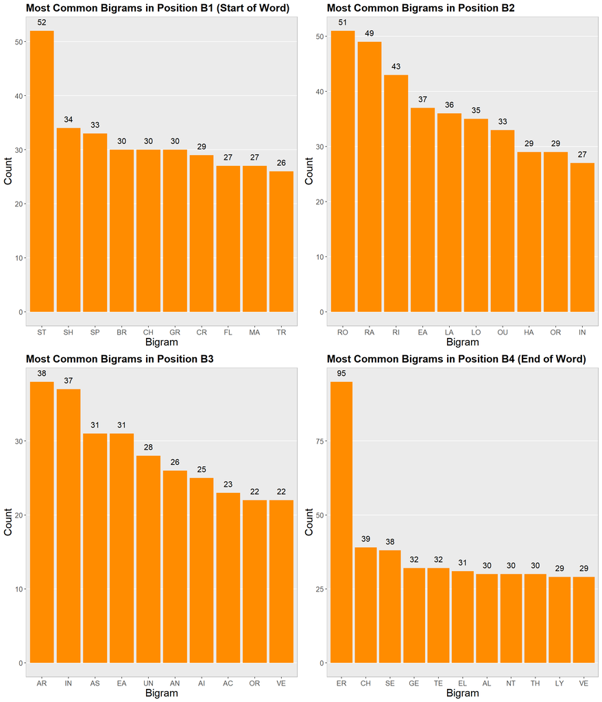

When broken down by position, clear patterns emerge. B1, the word’s opening bigram, frequently contains ST, SH, SP, or BR, common prefixes in English. B4, representing the word’s final bigram, is dominated by endings such as ER, CH, SE, and GE. These are typical suffixes used to close many words. The middle positions, B2 and B3, often show vowel-consonant or consonant-vowel combinations, reflecting natural transitions in English word structure. While no single bigram dominates the middle positions, patterns like RO, RA, AR, and IN still appear frequently.

These positional differences highlight that bigrams behave differently depending on where they appear. Wordle solutions often start with consonant clusters and end with standard English suffixes. Understanding these patterns helps explain why some guesses can eliminate large groups of possibilities based on just a few letters.

# So *how* can we apply this?

Lets consider again a Wordle solution similar to BAKER, where the last two letters are unknown: BAK__. Possible completions could include:

- BAKED
- BAKER
- BAKES

So from our bigram positional data we will find the occurrences of ED, ED, and ES in bigram position 4 (B4)

| Position | Bigram | Counts |
| --- | --- | --- |
| B4 | ER | 95 |
| B4 | ED | 7 |

From the data frequencies in B4 are as follows:

- ED occurs 7 times
- ER occurs 95 times
- ES occurs 0 times

So based on our positional bigram data we can assume that the most likely solution is BAKER.

## FUN FACT AGAIN!

Interestingly, the bigram data further supports my observation about rare plurals!

In the final bigram position (B4), ES, a common suffix for plural forms, occurs 0 times across all Wordle solutions. This aligns with my earlier note that four-letter words extended to five letters by adding an “S” are uncommon.

So, not only does the heatmap show few words ending in “S,” but the bigram analysis confirms that typical plural endings like ES are practically absent in Wordle. This provides additional evidence that Wordle generally avoids pluralizing four-letter words to make five-letter solutions.

# Do repeated letter Wordle answers follow seasonal or monthly patterns across different years?

I’ve always wondered if Wordle’s selection algorithm follows any sort of pattern when choosing daily solutions. Are certain types of words clustered in specific months? Do repeated-letter words appear more often in some seasons than others? To explore this, I plotted the number of repeated-letter Wordle answers per month across multiple years.

| Year | Month | repeats |
| --- | --- | --- |
| 2021 | June | 7 |
| 2021 | July | 11 |
| 2021 | August | 14 |
| 2021 | September | 12 |
| 2021 | October | 13 |
| 2021 | November | 6 |
| 2021 | December | 4 |
| 2022 | January | 8 |
| 2022 | February | 9 |
| 2022 | March | 9 |
| 2022 | April | 5 |
| 2022 | May | 7 |
| 2022 | June | 9 |
| 2022 | July | 14 |
| 2022 | August | 8 |
| 2022 | September | 12 |
| 2022 | October | 9 |
| 2022 | November | 6 |
| 2022 | December | 8 |
| 2023 | January | 9 |
| 2023 | February | 12 |
| 2023 | March | 7 |
| 2023 | April | 8 |
| 2023 | May | 7 |
| 2023 | June | 10 |
| 2023 | July | 7 |
| 2023 | August | 10 |
| 2023 | September | 8 |
| 2023 | October | 6 |
| 2023 | November | 10 |
| 2023 | December | 8 |
| 2024 | January | 6 |
| 2024 | February | 10 |
| 2024 | March | 7 |
| 2024 | April | 6 |
| 2024 | May | 9 |
| 2024 | June | 10 |
| 2024 | July | 9 |
| 2024 | August | 5 |
| 2024 | September | 9 |
| 2024 | October | 10 |
| 2024 | November | 13 |
| 2024 | December | 6 |
| 2025 | January | 13 |
| 2025 | February | 12 |
| 2025 | March | 10 |
| 2025 | April | 11 |
| 2025 | May | 11 |
| 2025 | June | 10 |
| 2025 | July | 10 |
| 2025 | August | 11 |
| 2025 | September | 7 |
| 2025 | October | 12 |
| 2025 | November | 4 |

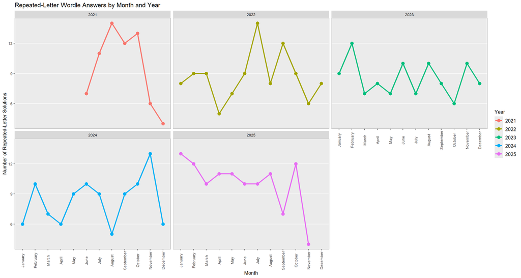

The line graphs show the counts of repeated letter words month by month for each year. As seen, the numbers fluctuate unpredictably from month to month and year to year. There is no clear seasonal or temporal trend, suggesting that the puzzle selection algorithm does not follow a predictable pattern when placing repeated-letter words.

To further visualize this, I created monthly heatmaps marking days with repeated-letter answers. While the full set of calendars can be extensive, a single example for January illustrates the approach. Each year’s January is displayed side by side, with light blue squares highlighting days containing repeated letter solutions. These heatmaps confirm the observations from the line graphs: the placement of repeated letter words appears largely random with no obvious clustering or rhythmic pattern across years.

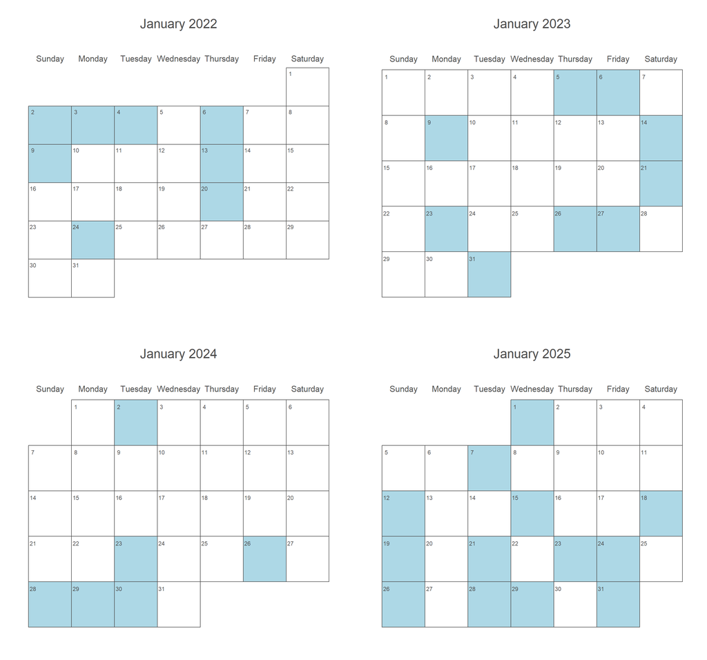

Based on the calendars and the heatmap, the distribution of words with repeated letters does not show a consistent pattern across months or years. Some months have clusters, others don’t, and the locations of repeated-letter days shift around unpredictably.

This suggests that the puzzle selection process does not follow a noticeable monthly or seasonal trend regarding repeated letters. In other words, the generator isn’t cycling through repeated-letter words in a predictable way; the placement looks random, or at least not influenced by simple time-based rules.

# Is there a relationship between a word’s frequency in English and its Scrabble point value?

Wordle words vary in both their frequency in the English language and their Scrabble score. One might expect that rarer words, which are less commonly used, would contain more unusual letters like Q, Z, or X and therefore have higher Scrabble scores. Conversely, more common words might use more frequent letters like E, A, or R and tend to have lower Scrabble values. By examining how Scrabble scores vary across words of different frequency categories, we can explore whether Wordle favors high-scoring words or if score and frequency are largely independent.

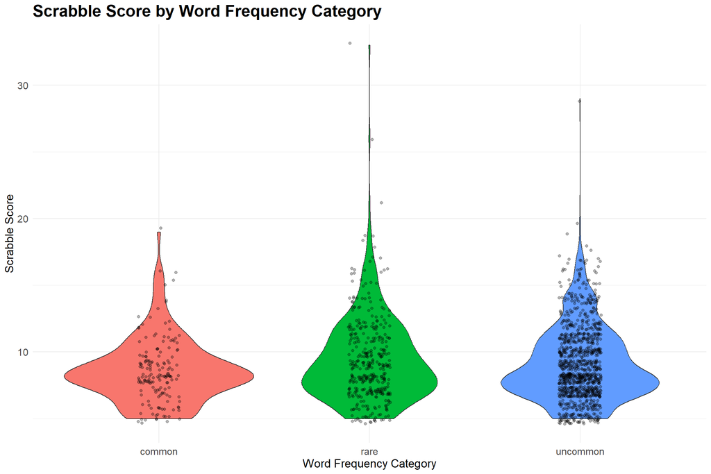

The violin plot shows the distribution of Scrabble scores for rare, uncommon, and common Wordle words. Interestingly, there is no strong correlation between a word’s frequency and its Scrabble score. Rare words do not consistently have higher scores, and common words do not always have lower scores.

## Fun Data

Now lets take a look at some of our highest scoring words.

### Wordle with the lowest corpus frequency

| Answer | Word.Frequency | Frequency.category |
| --- | --- | --- |
| WOOER | 0 | rare |

### Wordle with the highest corpus frequency

| Answer | Word.Frequency | Frequency.category |
| --- | --- | --- |
| ABOUT | 0.00251 | common |

### Three lowest Scrabble score Wordles per frequency category

| Answer | Scrabble.score | Frequency.category |
| --- | --- | --- |
| LATER | 5 | common |
| LEAST | 5 | common |
| UNION | 5 | common |
| ELATE | 5 | rare |
| LORIS | 5 | rare |
| STILT | 5 | rare |
| ARISE | 5 | uncommon |
| STUNT | 5 | uncommon |
| TENOR | 5 | uncommon |

### Three highest Scrabble score Wordles per frequency category

| Answer | Scrabble.score | Frequency.category |
| --- | --- | --- |
| CRAZY | 19 | common |
| CHECK | 16 | common |
| WHICH | 16 | common |
| JAZZY | 33 | rare |
| TIZZY | 26 | rare |
| JIFFY | 21 | rare |
| FUZZY | 29 | uncommon |
| QUICK | 20 | uncommon |
| JERKY | 19 | uncommon |

# Summary

This analysis of 1,600+ Wordle solutions uncovers both predictable patterns and surprising gaps in the game’s word selection:

- Letter and positional patterns:
  - Words often start with common consonant clusters (ST, SH, BR) and end with frequent suffixes (ER, CH, GE).
  - Vowels tend to appear in middle positions, reflecting natural English structure.
- Bigrams reveal structure:
  - Common letter pairs like ER, IN, and ST dominate specific positions, helping explain why certain guesses narrow possibilities faster.
- Rare plurals:
  - Words ending in “S” or the bigram “ES” are extremely uncommon, confirming that Wordle generally avoids pluralizing four-letter words.
- Repeated letters:
  - Words with repeated letters appear randomly across months and years, showing no seasonal or temporal patterns.
- Scrabble scores vs. frequency:
  - High-scoring words are driven by rare letters (Z, Q, X), while common letters keep scores low.
  - Word frequency in English does not strongly predict Scrabble value.

Takeaway:

Wordle solutions may feel random, but they follow subtle English patterns. Recognizing these trends like common prefixes, suffixes, letter positions, and high value letters, can improve guessing strategies and give players a structured approach to solving puzzles.